# 中文文本資料處理 (W10)

2019-11-14

## 斷詞

jieba 是一個用於中文斷詞的 (Python) 套件。[`jiebaR`](https://github.com/qinwf/jiebaR) 則是 jieba 的 R 版本。

使用 `jiebaR` 進行斷詞只須兩個步驟：

1. 使用 `worker()` 初始化斷詞設定
2. 使用 `segment()` 將文字斷詞
- `jiebaR::segment()` 回傳一個 character vector，vector 內的每個元素都是一個被斷出來的詞：

  ```r
  library(jiebaR)
  seg <- worker()
  txt <- "失業的熊讚陪柯文哲看銀翼殺手"
  segment(txt, seg)
  ```

  ```
  #> [1] "失業" "的熊" "讚"   "陪"   "柯文" "哲看" "銀翼" "殺手"
  ```

- `jiebaR` 的斷詞有時會不太精準，尤其是遇到**專有名詞或是特殊詞彙**時，這些詞彙時常會被斷開。若想避免這種情況，可以新增一份自訂辭典 (儲存在一份純文字檔，每個詞佔一行)，例如 `user_dict.txt` 的內容如下：

  ```
  熊讚
  柯文哲
  銀翼殺手
  ```

  如此在 `worker()` 中設定自訂辭典，`jiebaR` 就不會將這些詞彙斷開：

  ```r
  # With user dict
  seg <- worker(user = "user_dict.txt")
  segment(txt, seg)
  ```

  ```
  #> [1] "失業"     "的"       "熊讚"     "陪"       "柯文哲"   "看"
  #> [7] "銀翼殺手"
  ```

## 使用 data frame 建立語料庫

我們的目標是建立一個 data frame 儲存文本資料。在這個 data frame 中，每一個 row 代表一篇文章，每個變項 (column) 記錄著該篇文章的某個資訊。根據文本資料的來源，該 data frame 可能會有不同數量的變項，例如，「文章發表日期」、「作者」、「標題」、「主題」等。但最重要的是，此 data frame **至少**需具備**兩個變項** — 「文章 id」與「(斷完詞的) 文章內文」。下方使用一個簡單的例子 (3 篇文章) 說明如何建立這種 data frame。

- 第一步是將 `docs` 內的各篇文章 (character vector) 進行斷詞，並在斷完詞後，將文章的內容存入另一個**等長**的 character vector 中。同篇文章中，被斷開的詞之間以一個**空白字元**分隔:

  ```r
  library(jiebaR)

  # Data: 3 篇文章
  docs <- c(
    "蝴蝶和蜜蜂們帶著花朵的蜜糖回來了，羊隊和牛群告別了田野回家了，火紅的太陽也滾著火輪子回家了，當街燈亮起來向村莊道過晚安，夏天的夜就輕輕地來了。",
    "朋友買了一件衣料，綠色的底子帶白色方格，當她拿給我們看時，一位對圍棋十分感與趣的同學說：「啊，好像棋盤似的。」「我看倒有點像稿紙。」我說。「真像一塊塊綠豆糕。」一位外號叫「大食客」的同學緊接著說。",
    "每天，天剛亮時，我母親便把我喊醒，叫我披衣坐起。我從不知道她醒來坐了多久了。她看我清醒了，便對我說昨天我做錯了什麼事，說錯了什麼話，要我認錯，要我用功讀書。"
    )

  # Initialize jiebaR
  seg <- worker()

  docs_segged <- rep("", 3)
  for (i in seq_along(docs)) {
    # Segment each element in docs
    segged <- segment(docs[i], seg)

    # Collapse the character vector into a string, separated by space
    docs_segged[i] <- paste0(segged, collapse = " ")
  }

  docs_segged
  ```

  ```
  #> [1] "蝴蝶 和 蜜蜂 們 帶 著 花朵 的 蜜糖 回來 了 羊隊 和 牛群 告別 了 田野 回家 了 火紅 的 太陽 也 滾 著火 輪子 回家 了 當 街燈 亮 起來 向 村莊 道過 晚安 夏天 的 夜 就 輕輕地 來 了"
  #> [2] "朋友 買 了 一件 衣料 綠色 的 底子 帶 白色 方格 當 她 拿給 我們 看時 一位 對 圍棋 十分 感與趣 的 同 學說 啊 好像 棋盤 似的 我 看 倒 有點像 稿紙 我 說 真 像 一塊塊 綠豆糕 一位 外號 叫 大 食客 的 同學 緊接著 說"
  #> [3] "每天 天剛亮 時 我 母親 便 把 我 喊醒 叫 我 披衣 坐起 我 從不 知道 她 醒來 坐 了 多久 了 她 看 我 清醒 了 便 對 我 說 昨天 我 做 錯 了 什麼 事 說錯 了 什麼 話 要 我 認錯 要 我 用功讀書"
  ```

- 如此，我們就能使用這個斷完詞的 `docs_segged` 製作 data frame:

  ```r
  docs_df <- data.frame(
    doc_id = seq_along(docs_segged),
    content = docs_segged,
    stringsAsFactors = FALSE
  )

  knitr::kable(docs_df, align = "c")
  ```

  | doc_id | content |
  | --- | --- |
  | 1 | 蝴蝶 和 蜜蜂 們 帶 著 花朵 的 蜜糖 回來 了 羊隊 和 牛群 告別 了 田野 回家 了 火紅 的 太陽 也 滾 著火 輪子 回家 了 當 街燈 亮 起來 向 村莊 道過 晚安 夏天 的 夜 就 輕輕地 來 了 |
  | 2 | 朋友 買 了 一件 衣料 綠色 的 底子 帶 白色 方格 當 她 拿給 我們 看時 一位 對 圍棋 十分 感與趣 的 同 學說 啊 好像 棋盤 似的 我 看 倒 有點像 稿紙 我 說 真 像 一塊塊 綠豆糕 一位 外號 叫 大 食客 的 同學 緊接著 說 |
  | 3 | 每天 天剛亮 時 我 母親 便 把 我 喊醒 叫 我 披衣 坐起 我 從不 知道 她 醒來 坐 了 多久 了 她 看 我 清醒 了 便 對 我 說 昨天 我 做 錯 了 什麼 事 說錯 了 什麼 話 要 我 認錯 要 我 用功讀書 |

## tidytext framework

- `tidytext` 套件是 R 生態圈中比較近期的 text mining 套件，它將 tidyverse 的想法運用到文本資料處理上，換言之，就是使用 data frame 的資料結構去表徵和處理文本資料。
- 使用 `tidytext` 的方法處理文本資料有好有壞。
  - 好處是使用者能輕易地結合 `dplyr` 與 `ggplot2` 於文本分析中，因而能快速地視覺化文本資料。
  - 壞處是，在 `tidytext` framework 之下，文章的**內部 (i.e. 詞彙與詞彙之間的) 結構**會消失，因為它對於文本的想法是 [bag-of-words](https://en.wikipedia.org/wiki/Bag-of-words_model)。

    `tidytext` 所倡導的儲存文本資料的格式是 **one-token-per-document-per-row**，亦即，在一個 data frame 中，每一橫列 (row) 是一篇文章中的一個 token。因此，若有兩篇文章，第一篇被斷成 38 個詞彙，第二篇被斷成 20 個詞彙，則共需要一個 58 列 (row) 的 data frame 來儲存這兩篇文章。
- 一般而言，tidytext 的架構適合用於**與詞頻有關**的分析，例如，計算文章的 [lexical diversity](https://en.wikipedia.org/wiki/Lexical_diversity) 或是透過情緒詞的詞頻進行情緒分析。
- 透過 `tidytext::unnest_tokens()`，我可以將 `docs_df` 中儲存之 (已斷詞) 文本資料，變成 tidytext format，i.e.，**one-token-per-document-per-row** 的 data frame:

  ```r
  library(tidytext)
  library(dplyr)

  tidy_text_format <- docs_df %>%
    unnest_tokens(output = "word", input = "content",
                  token = "regex", pattern = " ")

  tidy_text_format
  ```

  ```
  #>     doc_id     word
  #> 1        1     蝴蝶
  #> 2        1       和
  #> 3        1     蜜蜂
  #> 4        1       們
  #> 5        1       帶
  #> 6        1       著
  #> 7        1     花朵
  #> 8        1       的
  #> 9        1     蜜糖
  #> 10       1     回來
  #> 11       1       了
  #> 12       1     羊隊
  #> 13       1       和
  #> 14       1     牛群
  ```

  [output cut: 125 more lines]

### 詞頻表

- 可以使用 `dplyr` 的 `group_by()` 與 `summarise()` 計算詞頻表：

  ```r
  tidy_text_format %>%
    group_by(word) %>%
    summarise(n = n()) %>%
    arrange(desc(n))
  ```

  ```
  #> # A tibble: 99 x 2
  #>    word      n
  #>    <chr> <int>
  #>  1 了       11
  #>  2 我       11
  #>  3 的        6
  #>  4 她        3
  #>  5 說        3
  #>  6 一位      2
  #>  7 什麼      2
  #>  8 便        2
  #>  9 叫        2
  #> 10 和        2
  #> # … with 89 more rows
  ```

  ```r
  # Equivalent to ...
  tidy_text_format %>%
    count(word) %>%
    arrange(desc(n))
  ```

  ```
  #> # A tibble: 99 x 2
  #>    word      n
  #>    <chr> <int>
  #>  1 了       11
  #>  2 我       11
  #>  3 的        6
  #>  4 她        3
  #>  5 說        3
  #>  6 一位      2
  #>  7 什麼      2
  #>  8 便        2
  #>  9 叫        2
  #> 10 和        2
  #> # … with 89 more rows
  ```

- 計算每篇文章的 lexical diversity (type-token ratio)：

  ```r
  tidy_text_format %>%
    group_by(doc_id, word) %>%
    summarise(n = n()) %>%  # Calculate token freq.
    ungroup() %>%
    group_by(doc_id) %>%
    summarise(TTR = n() / sum(n))  # Calculate type/token ratio
  ```

  ```
  #> # A tibble: 3 x 2
  #>   doc_id   TTR
  #>    <int> <dbl>
  #> 1      1 0.814
  #> 2      2 0.896
  #> 3      3 0.667
  ```

### 視覺化

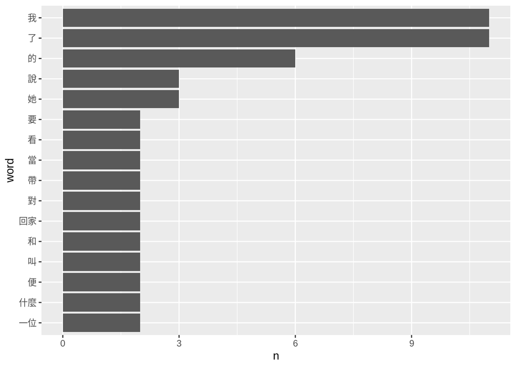

```r
library(ggplot2)
tidy_text_format %>%
  count(word) %>%
  mutate(word = reorder(word, n)) %>%   # 依照 n 排序文字
  top_n(10, n) %>%                      # 取 n 排名前 10 者
  ggplot() +
    geom_bar(aes(word, n), stat = "identity") +
    coord_flip()
```

## quanteda framework

傳統 R 的 text mining 生態圈中，使用的是另一種 (高階) 資料結構儲存文本資料 — 語料庫 (corpus)。[不同的套件有自己定義 corpus 的方式](https://quanteda.io/articles/pkgdown/comparison.html)，且各自進行文本分析的流程與想法差異頗大。目前最流行、支援最多的兩個套件是 [`quanteda`](https://quanteda.io/index.html) 與 [`tm`](http://tm.r-forge.r-project.org)。其中，`quanteda` 在中文支援以及說明與[教學](https://tutorials.quanteda.io)文件的完整度較高。

下方為 `quanteda` 套件的一些使用範例。欲比較完整地了解 `quanteda`，請閱讀 [quanteda tutorials](https://tutorials.quanteda.io)。

- 使用 `quanteda` 的好處在於它保留了文章的內部結構，例如，可以透過 `quanteda::kwic()` 去檢視特定詞彙或是片語出現的語境。與此同時，`quanteda` 也提供許多 bag-of-words 想法之下的函數。
- 但 `quanteda` 的缺點在於其內容龐雜，需要一些語料庫語言學的背景知識以及相當的時間摸索才能掌握。

```r
library(quanteda)

# 將 data frame 轉換成 Corpus object
quanteda_corpus <- corpus(docs_df,
                          docid_field = "doc_id",
                          text_field = "content")
```

- [Key Word in Context](https://en.wikipedia.org/wiki/Key_Word_in_Context)

  ```r
  # tokenize the corpus
  # (因為已先斷過詞, 使用 "fastestword", 即 空白字元 作為 tokenize 的方式)
  qcorp_tokens <- tokens(quanteda_corpus, "fastestword")

  kwic(qcorp_tokens, "我", window = 5, valuetype = "regex") %>%
    knitr::kable(align = "c")
  ```

  | docname | from | to | pre | keyword | post | pattern |
  | --- | --- | --- | --- | --- | --- | --- |
  | 2 | 15 | 15 | 白色 方格 當 她 拿給 | 我們 | 看時 一位 對 圍棋 十分 | 我 |
  | 2 | 29 | 29 | 學說 啊 好像 棋盤 似的 | 我 | 看 倒 有點像 稿紙 我 | 我 |
  | 2 | 34 | 34 | 我 看 倒 有點像 稿紙 | 我 | 說 真 像 一塊塊 綠豆糕 | 我 |
  | 3 | 4 | 4 | 每天 天剛亮 時 | 我 | 母親 便 把 我 喊醒 | 我 |
  | 3 | 8 | 8 | 時 我 母親 便 把 | 我 | 喊醒 叫 我 披衣 坐起 | 我 |
  | 3 | 11 | 11 | 便 把 我 喊醒 叫 | 我 | 披衣 坐起 我 從不 知道 | 我 |
  | 3 | 14 | 14 | 喊醒 叫 我 披衣 坐起 | 我 | 從不 知道 她 醒來 坐 | 我 |
  | 3 | 25 | 25 | 了 多久 了 她 看 | 我 | 清醒 了 便 對 我 | 我 |
  | 3 | 30 | 30 | 我 清醒 了 便 對 | 我 | 說 昨天 我 做 錯 | 我 |
  | 3 | 33 | 33 | 便 對 我 說 昨天 | 我 | 做 錯 了 什麼 事 | 我 |
  | 3 | 44 | 44 | 說錯 了 什麼 話 要 | 我 | 認錯 要 我 用功讀書 | 我 |
  | 3 | 47 | 47 | 話 要 我 認錯 要 | 我 | 用功讀書 | 我 |

- Lexical Diversity (比較上方 tidytext 詞頻表)

  ```r
  textstat_lexdiv(qcorp_tokens)
  ```

  ```
  #>   document       TTR
  #> 1        1 0.8139535
  #> 2        2 0.8958333
  #> 3        3 0.6666667
  ```

- 繪製文字雲：

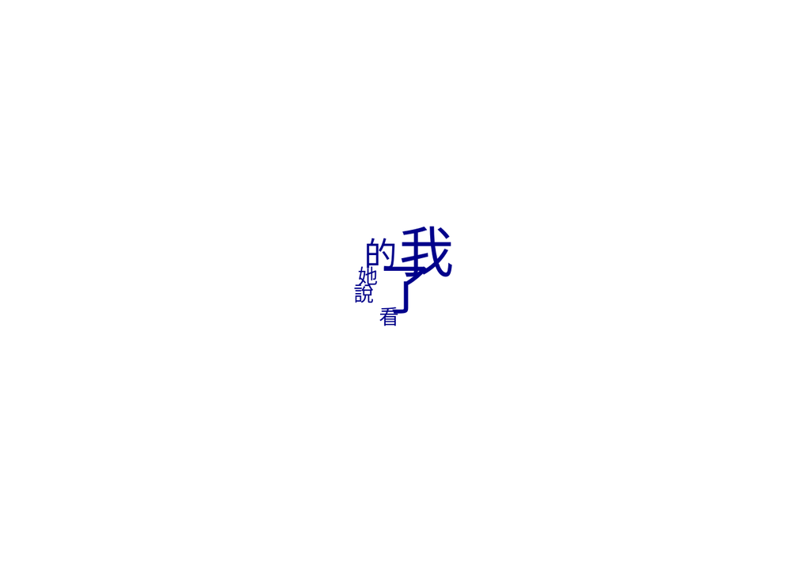

  ```r
  document_term_matrix <- dfm(quanteda_corpus)
  textplot_wordcloud(document_term_matrix)
  ```